# Evaluation of Sigma rule consistency

### 1. Load the conductect data into python.

```python
import pandas as pd
df = pd.read_json('../real-data-100.json')
print(df)
```

```
                                              samples
0   {'hash': 'a1ed46df50f5be3a6b3b291189d115bcccb9...
1   {'hash': '13144b87810fe4739e4e7078968b49e7ca4b...
2   {'hash': '8710679cc4055b4ed025b3be8a9b248a3ca4...
3   {'hash': 'f9043ef5ec8506f52efd3f8e1f9dc53b8c51...
4   {'hash': 'f636d54bf66339ab983cf31e259c8af64bdb...
..                                                ...
95  {'hash': 'ee9cebf9aaeb69e2f70c588c551a85dbdb9c...
96  {'hash': 'd509087303bb0f0d4710410f437844928d43...
97  {'hash': 'c13ea062e1f95644caadecc45351ed4b7d9c...
98  {'hash': '7b9e3a1daae553787702cc7245c8aa6d569c...
99  {'hash': 'f93faf0aef75fd22d3d5358389b6c2857b91...

[100 rows x 1 columns]
```

### 2. Display statistics for the loaded data.

```python
print("Number of Malware Samples: ", len(df['samples']))
print("Number of Rules: ", len(df['samples'][0]['rules']))
```

```
Number of Malware Samples:  100
Number of Rules:  78
```

### 3. Evaluate the Sigma rules that are consistent across all three systems.

#### 3.1 Categorization of 3-consistency.

The results are categorized within the following groups:

- **Group A:** Always Consistent
- **Group B:** Sometimes Consistent
- **Group C:** Never Consistent
- **Group D:** Other

```python
consistent = {}
total_detection = {}

for malware in df['samples']:

    for rule in malware['rules']:
        # all 0 -> continue
        if rule['i'] == 0 and rule['e'] == 0 and rule['s'] == 0:
            continue

        if not total_detection.get(rule['title']):
            total_detection[rule['title']] = 1
        else:
            total_detection[rule['title']] += 1


        values = set({rule['i'], rule['e'], rule['s']})


        # all are the same
        if len(values) == 1:

            # not in output because first time appeared
            if not consistent.get(rule['title']):
                consistent[rule['title']] = 1
            else:
                consistent[rule['title']] += 1


group_a = {} #always
group_b = {} #sometimes
group_c = {} #never
group_d = {} #other

for detection in total_detection:

    # if detection is consistent at least once add to group a or b
    if consistent.get(detection):
        tmp = {
                "consistent": consistent[detection],
                "total": total_detection[detection]
        }
        if consistent[detection] == total_detection[detection]:
            group_a[detection] = tmp
        else:
            group_b[detection] = tmp

    else:
        group_c[detection] = {
            "consistent": 0,
            "total": total_detection[detection]
        }


for rule in df['samples'][0]['rules']:
      if rule['title'] not in total_detection.keys():
          group_d[rule['title']] = {
            "consistent": 0,
            "total": 0
        }

print("A: ", len(group_a))
print("------------------------")
print("B: ", len(group_b))
print("------------------------")
print("C: ", len(group_c))
print("------------------------")
print("D: ", len(group_d))
print("---------Total----------")
print(f"{len(group_a)+len(group_b)+len(group_c)+len(group_d)}")
```

```
A:  22
------------------------
B:  6
------------------------
C:  49
------------------------
D:  1
---------Total----------
78
```

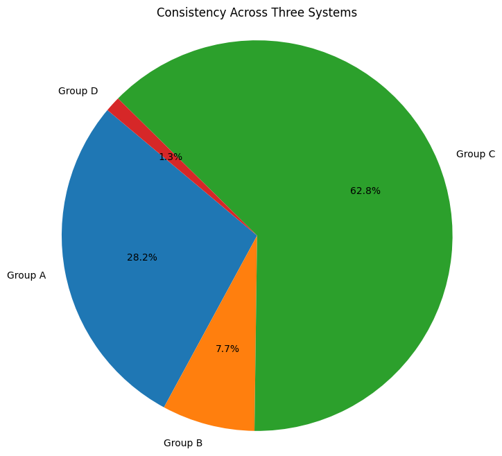

```python
import matplotlib.pyplot as plt

# Lengths of the lists
lengths = [len(group_a), len(group_b), len(group_c), len(group_d)]

# Labels for the pie chart
labels = ['Group A', 'Group B', 'Group C', 'Group D']

# Plotting the pie chart
plt.figure(figsize=(8, 8))
plt.pie(lengths, labels=labels, autopct='%1.1f%%', startangle=140)

plt.axis('equal')  # Equal aspect ratio ensures that pie is drawn as a circle.
plt.title('Consistency Across Three Systems')
plt.show()
```

#### 3.2 Classify the reason for inconsistent dectection rates for rules assigned to Group B

The classification process involved examining the generated table below and analyzing the results. By reviewing the Elastic-Total, Splunk-Total, and Insight-Total values alongside their corresponding detections, it was evident which rules failed due to inconsistent conversion and which ones were affected by data inconsistency.

```python
data = {
    "Rule": [],
    "Elastic-Total": [],
    "Splunk-Total": [],
    "Insight-Total": [],
    "e": [],
    "s": [],
    "i": [],
    "comment": [],
}

for i_rule, value in group_b.items():

    for malware in df['samples']:

        for rule in malware['rules']:
            if rule['i'] == 0 and rule['e'] == 0 and rule['s'] == 0:
                continue

            set_count = set([malware['s_events_total'], malware['e_events_total'], malware['i_events_total']])
            if len(set_count) == 1:
                #print(f"INCONSISTENT: s={malware['s_events_total']} | e={malware['e_events_total']} | i={malware['i_events_total']}  |  Rule: {rule}")
                continue

            if rule['s'] == rule['e'] and rule['s'] == rule['i'] and rule['e'] == rule['i']:
                continue

            if rule['title'] == i_rule:
                data['Rule'].append(rule['title'])
                data['Elastic-Total'].append(malware['e_events_total'])
                data['Splunk-Total'].append(malware['s_events_total'])
                data['Insight-Total'].append(malware['i_events_total'])
                data['e'].append(rule['e'])
                data['s'].append(rule['s'])
                data['i'].append(rule['i'])
                #print(f"TOTALS: s={malware['s_events_total']} | e={malware['e_events_total']} | i={malware['i_events_total']}  |  Rule: {rule}")

data['comment'].append("inconsistent: Elastic/Splunk same total") #1
data['comment'].append("-") #2
data['comment'].append("inconsistent: Elastic/Splunk same total") #3
data['comment'].append("inconsistent: Elastic/Splunk same total") #4
data['comment'].append("-") #5
data['comment'].append("-") #6
data['comment'].append("inconsistent: Insight less data but more detection") #7
data['comment'].append("-") #8
data['comment'].append("inconsistent: Elastic/Splunk same total") #9
data['comment'].append("-") #10
data['comment'].append("-") #11
data['comment'].append("-") #12
data['comment'].append("-") #13
data['comment'].append("-") #14
data['comment'].append("-") #15
data['comment'].append("-") #16
data['comment'].append("-") #17
data['comment'].append("-") #18
data['comment'].append("-") #19
data['comment'].append("-") #20
data['comment'].append("-") #21
data['comment'].append("-") #22
data['comment'].append("-") #23
data['comment'].append("-") #24
data['comment'].append("-") #25
data['comment'].append("-") #26
data['comment'].append("-") #27
data['comment'].append("-") #28
data['comment'].append("-") #29
data['comment'].append("-") #30
data['comment'].append("-") #31
data['comment'].append("-") #32
data['comment'].append("-") #33
data['comment'].append("-") #34
data['comment'].append("inconsistent: Only two events total missing but 30 not detected.") #35
data['comment'].append("inconsistent: Elastic/Splunk same total") #36
data['comment'].append("inconsistent: Elastic/Splunk same total") #37
data['comment'].append("-") #38

df2 = pd.DataFrame(data)
display(df2.style.set_properties(**{'text-align': 'center'}))
```

|  | Rule | Elastic-Total | Splunk-Total | Insight-Total | e | s | i | comment |
| --- | --- | --- | --- | --- | --- | --- | --- | --- |
| 0 | Non Interactive PowerShell Process Spawned | 57 | 57 | 39 | 1 | 3 | 0 | inconsistent: Elastic/Splunk same total |
| 1 | Non Interactive PowerShell Process Spawned | 45 | 52 | 53 | 1 | 4 | 4 | - |
| 2 | Non Interactive PowerShell Process Spawned | 244 | 244 | 243 | 6 | 8 | 8 | inconsistent: Elastic/Splunk same total |
| 3 | Non Interactive PowerShell Process Spawned | 62 | 62 | 53 | 1 | 3 | 3 | inconsistent: Elastic/Splunk same total |
| 4 | Non Interactive PowerShell Process Spawned | 73 | 73 | 64 | 4 | 4 | 3 | - |
| 5 | Use Short Name Path in Command Line | 52 | 56 | 14 | 1 | 1 | 0 | - |
| 6 | Use Short Name Path in Command Line | 830 | 830 | 829 | 6 | 6 | 7 | inconsistent: Insight less data but more detection |
| 7 | Use Short Name Path in Command Line | 10000 | 21412 | 20995 | 10000 | 10734 | 10524 | - |
| 8 | Suspicious Script Execution From Temp Folder | 244 | 244 | 243 | 0 | 1 | 1 | inconsistent: Elastic/Splunk same total |
| 9 | Unsigned DLL Loaded by RunDLL32/RegSvr32 | 67 | 67 | 43 | 1 | 1 | 0 | - |
| 10 | Unsigned DLL Loaded by RunDLL32/RegSvr32 | 85 | 84 | 68 | 1 | 1 | 0 | - |
| 11 | Unsigned DLL Loaded by RunDLL32/RegSvr32 | 61 | 61 | 41 | 1 | 1 | 0 | - |
| 12 | Unsigned DLL Loaded by RunDLL32/RegSvr32 | 57 | 57 | 39 | 1 | 1 | 0 | - |
| 13 | Unsigned DLL Loaded by RunDLL32/RegSvr32 | 67 | 58 | 56 | 1 | 0 | 0 | - |
| 14 | Unsigned DLL Loaded by RunDLL32/RegSvr32 | 65 | 65 | 47 | 1 | 1 | 0 | - |
| 15 | Unsigned DLL Loaded by RunDLL32/RegSvr32 | 153 | 153 | 125 | 1 | 1 | 0 | - |
| 16 | Unsigned DLL Loaded by RunDLL32/RegSvr32 | 67 | 67 | 49 | 1 | 1 | 0 | - |
| 17 | Unsigned DLL Loaded by RunDLL32/RegSvr32 | 75 | 75 | 59 | 1 | 1 | 0 | - |
| 18 | Unsigned DLL Loaded by RunDLL32/RegSvr32 | 75 | 75 | 50 | 1 | 1 | 0 | - |
| 19 | Unsigned DLL Loaded by RunDLL32/RegSvr32 | 75 | 74 | 52 | 1 | 1 | 0 | - |
| 20 | Unsigned DLL Loaded by RunDLL32/RegSvr32 | 77 | 78 | 42 | 1 | 1 | 0 | - |
| 21 | Unsigned DLL Loaded by RunDLL32/RegSvr32 | 90 | 88 | 70 | 7 | 7 | 6 | - |
| 22 | Unsigned DLL Loaded by RunDLL32/RegSvr32 | 122 | 122 | 97 | 1 | 1 | 0 | - |
| 23 | Unsigned DLL Loaded by RunDLL32/RegSvr32 | 61 | 63 | 45 | 1 | 1 | 0 | - |
| 24 | Unsigned DLL Loaded by RunDLL32/RegSvr32 | 60 | 60 | 43 | 1 | 1 | 0 | - |
| 25 | Unsigned DLL Loaded by RunDLL32/RegSvr32 | 60 | 61 | 44 | 1 | 1 | 0 | - |
| 26 | Unsigned DLL Loaded by RunDLL32/RegSvr32 | 50 | 50 | 28 | 1 | 1 | 0 | - |
| 27 | Unsigned DLL Loaded by RunDLL32/RegSvr32 | 68 | 68 | 43 | 1 | 1 | 0 | - |
| 28 | Unsigned DLL Loaded by RunDLL32/RegSvr32 | 172 | 174 | 148 | 1 | 1 | 0 | - |
| 29 | Unsigned DLL Loaded by RunDLL32/RegSvr32 | 82 | 81 | 61 | 1 | 1 | 0 | - |
| 30 | Unsigned DLL Loaded by RunDLL32/RegSvr32 | 55 | 55 | 31 | 1 | 1 | 0 | - |
| 31 | Unsigned DLL Loaded by RunDLL32/RegSvr32 | 160 | 160 | 146 | 1 | 1 | 0 | - |
| 32 | Unsigned DLL Loaded by RunDLL32/RegSvr32 | 72 | 72 | 53 | 1 | 1 | 0 | - |
| 33 | Unsigned DLL Loaded by RunDLL32/RegSvr32 | 72 | 71 | 52 | 1 | 1 | 0 | - |
| 34 | Windows Shell/Scripting Processes Spawning Suspicious Programs | 172 | 174 | 148 | 0 | 30 | 30 | inconsistent: Only two events total missing but 30 not detected. |
| 35 | Process Creation Using Sysnative Folder | 151 | 151 | 142 | 0 | 1 | 1 | inconsistent: Elastic/Splunk same total |
| 36 | Process Creation Using Sysnative Folder | 160 | 160 | 146 | 0 | 1 | 1 | inconsistent: Elastic/Splunk same total |
| 37 | Process Creation Using Sysnative Folder | 469 | 470 | 464 | 0 | 1 | 1 | - |

### 4. Evaluate the Sigma rules that are consistent across two systems.

#### 4.1 Categorization of 2-consistency regardless of the combination.

The results are categorized within the following groups:

- **Group A**: Always
- **Group B**: Not Always

```python
consistent_2 = {}
total_detection_2 = {}

for malware in df['samples']:

    for rule in malware['rules']:
        # all 0 -> continue (exclude group_d)
        if rule['i'] == 0 and rule['e'] == 0 and rule['s'] == 0:
            continue

        # all consistent -> continue (exclude group_a)
        if rule['s'] == rule['i'] and rule['s'] == rule['e'] and rule['e'] == rule['i']:
            continue


        if not total_detection_2.get(rule['title']):
            total_detection_2[rule['title']] = 1
        else:
            total_detection_2[rule['title']] += 1


        if rule['s'] == rule['e'] or rule['s'] == rule['i'] or rule['e'] == rule['i']:
            # if rule is inserted the first time
            if not consistent_2.get(rule['title']):



                consistent_2[rule['title']] = {
                    "se": 0,
                    "si": 0,
                    "ei": 0,
                    "consistent": 0,
                }

            se = 0
            si = 0
            ei = 0

            # splunk and insight
            if rule['s'] == rule['e']:
                se +=1
            elif rule['s'] == rule['i']:
                si += 1
            elif rule['e'] == rule['i']:
                ei += 1

            consistent_2[rule['title']] = {
                "se": consistent_2[rule['title']]['se'] + se,
                "si": consistent_2[rule['title']]['si'] + si,
                "ei": consistent_2[rule['title']]['ei'] + ei,
                "consistent": consistent_2[rule['title']]['consistent'] + 1,
            }


group_1 = {} # Always
group_2 = {} # Not Always
for key in total_detection_2:

    # if never two consistent add to group 3
    if not consistent_2.get(key):
        group_2[key] = {
            "se": 0,
            "si": 0,
            "ei": 0,
            "consistent": 0,
            "total": total_detection_2[key]
        }
        continue

    if consistent_2[key]['consistent'] == total_detection_2[key]:
        group_1[key] = {
            "se": consistent_2[key]['se'],
            "si": consistent_2[key]['si'],
            "ei": consistent_2[key]['ei'],
            "consistent": consistent_2[key]['consistent'],
            "total": total_detection_2[key]
        }
    else:
        group_2[key] = {
            "se": consistent_2[key]['se'],
            "si": consistent_2[key]['si'],
            "ei": consistent_2[key]['ei'],
            "consistent": consistent_2[key]['consistent'],
            "total": total_detection_2[key]
        }


print(len(group_1))
print(len(group_2))
import json
print(json.dumps(group_1, indent=4))
```

```
49
6
{
    "Driver Load From A Temporary Directory": {
        "se": 0,
        "si": 68,
        "ei": 0,
        "consistent": 68,
        "total": 68
    },
    "Sysmon Configuration Modification": {
        "se": 0,
        "si": 22,
        "ei": 0,
        "consistent": 22,
        "total": 22
    },
    "Potential Configuration And Service Reconnaissance Via Reg.EXE": {
        "se": 1,
        "si": 11,
        "ei": 0,
        "consistent": 12,
        "total": 12
    },
    "Change PowerShell Policies to an Insecure Level": {
        "se": 0,
        "si": 2,
        "ei": 1,
        "consistent": 3,
        "total": 3
    },
    "PSScriptPolicyTest Creation By Uncommon Process": {
        "se": 0,
        "si": 4,
        "ei": 0,
        "consistent": 4,
        "total": 4
    },
    "Potential Binary Or Script Dropper Via PowerShell": {
        "se": 0,
```

[output cut: 292 more lines]

```
    "Windows Shell/Scripting Processes Spawning Suspicious Programs": {
        "se": 0,
        "si": 1,
        "ei": 0,
        "consistent": 1,
        "total": 1
    },
    "WmiPrvSE Spawned A Process": {
        "se": 0,
        "si": 1,
        "ei": 0,
        "consistent": 1,
        "total": 1
    }
}
```

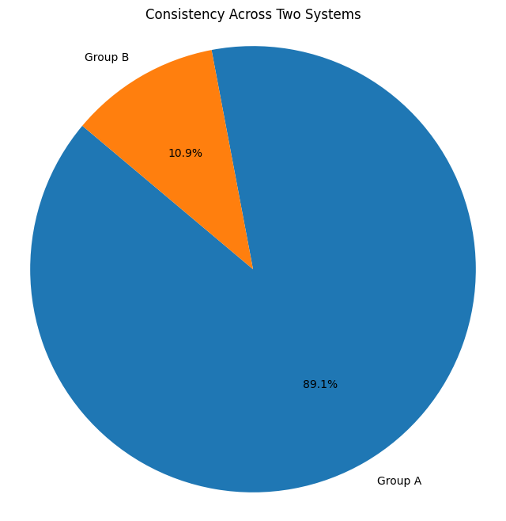

```python
import matplotlib.pyplot as plt

# Lengths of the lists
lengths = [len(group_1), len(group_2)]

# Labels for the pie chart
labels = ['Group A', 'Group B']

# Plotting the pie chart
plt.figure(figsize=(8, 8))
plt.pie(lengths, labels=labels, autopct='%1.1f%%', startangle=140)

plt.axis('equal')  # Equal aspect ratio ensures that pie is drawn as a circle.
plt.title('Consistency Across Two Systems')
plt.show()
```

#### 4.2 Categorization of 2-consistency based on the platform combination as bar chart.

```
34
233
8
```

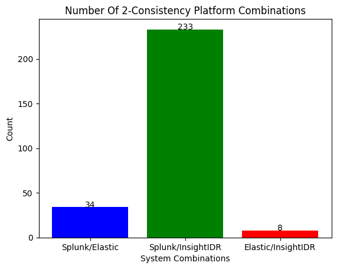

```
Percentage for count_se: 12
Percentage for count_si: 84
Percentage for count_ei: 2
```

```python
import matplotlib.pyplot as plt

count_se = 0
count_si = 0
count_ei = 0

# Lengths of the lists
for rule in group_1:
    count_se += group_1[rule]['se']
    count_si += group_1[rule]['si']
    count_ei += group_1[rule]['ei']

print(count_se)
print(count_si)
print(count_ei)

labels = ['Splunk/Elastic', 'Splunk/InsightIDR', 'Elastic/InsightIDR']
values = [count_se, count_si, count_ei]
plt.bar(labels, values, color=['blue', 'green', 'red'])
plt.xlabel('System Combinations')
plt.ylabel('Count')

# function to add value labels
def addlabels(x,y):
    for i in range(len(x)):
        plt.text(i, y[i], y[i], ha = 'center')

addlabels(["", "", ""], [count_se, count_si, count_ei])

plt.title('Number Of 2-Consistency Platform Combinations')
plt.show()

import math

# Calculate the total count
total_count = count_se + count_si + count_ei

# Calculate the percentages
percentage_se =  math.floor((count_se / total_count) * 100)
percentage_si =  math.floor((count_si / total_count) * 100)
percentage_ei =  math.floor((count_ei / total_count) * 100)

print("Percentage for count_se:", percentage_se)
print("Percentage for count_si:", percentage_si)
print("Percentage for count_ei:", percentage_ei)
```

#### 4.3 Categorization of 2-consistency based on the platform combination as table.

The yellow rows within the generated table highlight rules that are consistent across the same two SIEM systems. This suggests that these rules function well for two out of three systems, with the third potentially lacking some conversion logic. Rules with minimal escapes failed due to data inconsistency or improper conversion. Each deviation, i.e. the lines not marked in yellow, were manually checked for the reason for their error. The decision as to whether data inconsistency or faulty conversion was made on the basis of the total number of events collected by each of the three SIEM systems and the detection rate in the specific case.

```python
data = {
    'Rule': [],       # Rule Names
    'Splunk/Elastic': [],
    'Splunk/Insight': [],
    'Elastic/Insight': []
}

broken_or_inconsistent = []

for key, value in group_1.items():
    data['Rule'].append(key)
    data['Splunk/Elastic'].append(value['se'])
    data['Splunk/Insight'].append(value['si'])
    data['Elastic/Insight'].append(value['ei'])

df = pd.DataFrame(data)
#display(df.style.set_properties(**{'text-align': 'center'}))

def highlight_greaterthan(value):
    if value['Splunk/Elastic'] == 0 and value['Splunk/Insight'] == 0:
        return ['background-color: yellow', 'background-color: yellow', 'background-color: yellow', 'background-color: yellow']

    if value['Splunk/Elastic'] == 0 and value['Elastic/Insight'] == 0:
        return ['background-color: yellow', 'background-color: yellow', 'background-color: yellow', 'background-color: yellow']

    if value['Elastic/Insight'] == 0 and value['Splunk/Insight'] == 0:
        return ['background-color: yellow', 'background-color: yellow', 'background-color: yellow', 'background-color: yellow']

    broken_or_inconsistent.append(value['Rule'])
    return ['background-color: white', 'background-color: white', 'background-color: white', 'background-color: white']

df.style.apply(highlight_greaterthan, axis=1)
```

|  | Rule | Splunk/Elastic | Splunk/Insight | Elastic/Insight |
| --- | --- | --- | --- | --- |
| 0 | Driver Load From A Temporary Directory | 0 | 68 | 0 |
| 1 | Sysmon Configuration Modification | 0 | 22 | 0 |
| 2 | Potential Configuration And Service Reconnaissance Via Reg.EXE | 1 | 11 | 0 |
| 3 | Change PowerShell Policies to an Insecure Level | 0 | 2 | 1 |
| 4 | PSScriptPolicyTest Creation By Uncommon Process | 0 | 4 | 0 |
| 5 | Potential Binary Or Script Dropper Via PowerShell | 0 | 2 | 1 |
| 6 | Rare Remote Thread Creation By Uncommon Source Image | 1 | 9 | 0 |
| 7 | Startup Folder File Write | 0 | 2 | 1 |
| 8 | Greedy File Deletion Using Del | 0 | 0 | 3 |
| 9 | Remote Thread Creation By Uncommon Source Image | 0 | 20 | 0 |
| 10 | LOLBIN Execution From Abnormal Drive | 0 | 2 | 0 |
| 11 | CurrentVersion NT Autorun Keys Modification | 0 | 3 | 0 |
| 12 | CMD Shell Output Redirect | 0 | 4 | 0 |
| 13 | Delete All Scheduled Tasks | 0 | 2 | 0 |
| 14 | Disable Windows Defender Functionalities Via Registry Keys | 0 | 4 | 0 |
| 15 | Elevated System Shell Spawned From Uncommon Parent Location | 0 | 2 | 0 |
| 16 | Forfiles Command Execution | 0 | 1 | 0 |
| 17 | Reg Add Suspicious Paths | 0 | 2 | 0 |
| 18 | Scheduled Task Creation Via Schtasks.EXE | 0 | 11 | 0 |
| 19 | Suspicious Add Scheduled Task Parent | 0 | 4 | 0 |
| 20 | Suspicious Encoded PowerShell Command Line | 0 | 1 | 0 |
| 21 | Suspicious Execution of Powershell with Base64 | 0 | 1 | 0 |
| 22 | Suspicious PowerShell Invocations - Specific - ProcessCreation | 0 | 1 | 0 |
| 23 | Suspicious Scheduled Task Creation Involving Temp Folder | 0 | 1 | 0 |
| 24 | Suspicious Schtasks From Env Var Folder | 0 | 9 | 0 |
| 25 | Suspicious Schtasks Schedule Types | 0 | 1 | 0 |
| 26 | Suspicious Script Execution From Temp Folder | 0 | 1 | 0 |
| 27 | Suspicious Windows Defender Registry Key Tampering Via Reg.EXE | 0 | 1 | 0 |
| 28 | Windows Defender Exclusions Added - Registry | 0 | 1 | 0 |
| 29 | Read Contents From Stdin Via Cmd.EXE | 0 | 1 | 0 |
| 30 | Wow6432Node CurrentVersion Autorun Keys Modification | 0 | 7 | 0 |
| 31 | Wow6432Node Windows NT CurrentVersion Autorun Keys Modification | 7 | 0 | 0 |
| 32 | Modify User Shell Folders Startup Value | 0 | 3 | 0 |
| 33 | Process Creation Using Sysnative Folder | 0 | 3 | 0 |
| 34 | Set Files as System Files Using Attrib.EXE | 0 | 0 | 1 |
| 35 | Powershell Defender Exclusion | 0 | 9 | 0 |
| 36 | Suspicious Scheduled Task Creation via Masqueraded XML File | 0 | 5 | 0 |
| 37 | Unsigned DLL Loaded by RunDLL32/RegSvr32 | 24 | 1 | 0 |
| 38 | New Firewall Rule Added Via Netsh.EXE | 0 | 2 | 0 |
| 39 | Suspicious Outbound SMTP Connections | 0 | 2 | 0 |
| 40 | Bad Opsec Defaults Sacrificial Processes With Improper Arguments | 0 | 1 | 0 |
| 41 | Rundll32 Internet Connection | 0 | 1 | 0 |
| 42 | Abused Debug Privilege by Arbitrary Parent Processes | 0 | 1 | 0 |
| 43 | Suspicious Schtasks Schedule Type With High Privileges | 0 | 2 | 0 |
| 44 | Silenttrinity Stager Msbuild Activity | 0 | 1 | 0 |
| 45 | Suspicious Msbuild Execution By Uncommon Parent Process | 0 | 0 | 1 |
| 46 | Uncommon Child Process Of Conhost.EXE | 1 | 0 | 0 |
| 47 | Windows Shell/Scripting Processes Spawning Suspicious Programs | 0 | 1 | 0 |
| 48 | WmiPrvSE Spawned A Process | 0 | 1 | 0 |

1. Potential Configuration And Service Reconnaissance Via Reg.EXE
   - Total:

     ```
     "start_time": 1706180277047,
     "end_time": 1706180397047,
     "signature": "Formbook",
     "e_events_total": 56,
     "s_events_total": 55,
     "i_events_total": 57,
     ```

   - Detected:

     ```
     "e": 0,
     "s": 0,
     "i": 1
     ```

   - Explanation for inconsistency: Splunk exhibits two fewer events, indicating potential data inconsistency but appears consistent across two platforms.
2. Change PowerShell Policies to an Insecure Level
   - Total:

     ```
     "start_time": 1706179907800,
     "end_time": 1706180027800,
     "signature": "RemcosRAT",
     "e_events_total": 57,
     "s_events_total": 57,
     "i_events_total": 39,
     ```

   - Detected:

     ```
     "e": 0,
     "s": 1,
     "i": 0
     ```

   - Explanation for inconsistency: The lower number of events in InsightIDR may be attributed to data inconsistency.
3. Potential Binary Or Script Dropper Via PowerShell
   - Total:

     ```
     "start_time": 1706179907800,
     "end_time": 1706180027800,
     "signature": "RemcosRAT",
     "e_events_total": 57,
     "s_events_total": 57,
     "i_events_total": 39,
     ```

   - Detected:

     ```
     "e": 0,
     "s": 1,
     "i": 0
     ```

   - Explanation for inconsistency: The lower number of events in InsightIDR may be attributed to data inconsistency.
4. Rare Remote Thread Creation By Uncommon Source Image
   - Total:

     ```
     "start_time": 1706248655255,
     "end_time": 1706248775255,
     "signature": "DarkComet",
     "e_events_total": 70,
     "s_events_total": 70,
     "i_events_total": 58,
     ```

   - Detected:

     ```
     "e": 0,
     "s": 0,
     "i": 1
     ```

   - Explanation for inconsistency: Inconsistent due to InsightIDR having fewer events, yet it still manages to detect something, while the others found nothing.
5. Startup Folder File Write
   - Total:

     ```
     "start_time": 1706179907800,
     "end_time": 1706180027800,
     "signature": "RemcosRAT",
     "e_events_total": 57,
     "s_events_total": 57,
     "i_events_total": 39,
     ```

   - Detected:

     ```
     "e": 0,
     "s": 1,
     "i": 0
     ```

   - Explanation for inconsistency: The lower number of events in InsightIDR may be attributed to data inconsistency.
6. Unsigned DLL Loaded by RunDLL32/RegSvr32
   - Total:

     ```
     "start_time": 1706252491638,
     "end_time": 1706252611638,
     "signature": "AsyncRAT",
     "e_events_total": 67,
     "s_events_total": 58,
     "i_events_total": 56,
     ```

   - Detected:

     ```
     "e": 1,
     "s": 0,
     "i": 0
     ```

   - Explanation for inconsistency: Elastic has significantly more events than Splunk, which could indicate data inconsistency.

### 5. Evaluate the reasons for Sigma rules that are broken due to convertion issues.

Therefore all rules within 2-consistency Group A are analysed by hand. Each rule was manually executed against the execution time frame for each of the three platforms. As a result, the inconsistent system provided either more or fewer detections than the two others. By adjusting the inconsistent query until it received the same events as the others, errors within the con- version process were identified. All encountered failures have been labeled with the following error tags:

```python
mapping = "Key Mapping Error"
quote = "Used Double Quotes When Not Allowed Error"
capitalization = "Case Sensitive Word Error"
not_identifiable = "Non Identifiable Error"
syntax = "Convertion Syntax Error"
length = "Value To Long Can't Be Searched Error"

final_data = [
    {
        "rule": "Driver Load From A Temporary Directory",
        "tags": [mapping],
        "description": "The ImageLoaded attribute gets converted to file.path in Elasticsearch. In order to work properly, the Sysmon log-type Driver Loaded needs to be specified.",
    },
    {
        "rule": "Sysmon Configuration Modification",
        "tags": [quote],
        "description": "Use of double quotes in Elasticsearch when filtering for specific values. Elasticsearch does not exclude quotes from the searched word, like Splunk or InsightIDR.",
    },
    #{
     #   "rule": "Potential Configuration And Service Reconnaissance Via Reg.EXE",
      #  "tags": [capitalization],
       # "description": "While Splunk is case-insensitive by default, Elasticsearch is case-sensitive. The word currentcontrolset must be capitalized to CurrentControlSet.",
    #},
    #{
    #    "rule": "Change PowerShell Policies to an Insecure Level",
    #    "tags": [quote, capitalization],
    #    "description": "Use of double quotes in Elasticsearch when filtering for specific values. Elasticsearch does not exclude quotes from the searched word, like Splunk or InsightIDR. While Splunk is case-insensitive by default, Elasticsearch is case-sensitive. The word executionpolicy must be capitalized to ExecutionPolicy.",
    #},
    {
        "rule": "PSScriptPolicyTest Creation By Uncommon Process",
        "tags": [capitalization],
        "description": "While Splunk is case-insensitive by default, Elasticsearch is case-sensitive. When searching for powershell.exe, Powershell.exe must also be considered.",
    },
    #{
     #   "rule": "Potential Binary Or Script Dropper Via PowerShell",
      #  "tags": [capitalization],
       # "description": "While Splunk is case-insensitive by default, Elasticsearch is case-sensitive. When searching for powershell.exe, Powershell.exe must also be considered.",
    #},
    #{
    #    "rule": "Rare Remote Thread Creation By Uncommon Source Image",
    #    "tags": [not_identifiable],
    #    "description": "/",
    #},
    #{
     #   "rule": "Startup Folder File Write",
      #  "tags": [quote, capitalization],
       # "description": "Use of double quotes in Elasticsearch when filtering for specific values. Elasticsearch does not exclude quotes from the searched word, like Splunk or InsightIDR. While Splunk is case-insensitive by default, Elasticsearch is case-sensitive. The word StartUp must be capitalized to Startup.",
    #},
    {
        "rule": "Greedy File Deletion Using Del",
        "tags": [quote, syntax],
        "description": "Use of double quotes in Elasticsearch when filtering for specific values. Elasticsearch does not exclude quotes from the searched word, like Splunk or InsightIDR. Additionally, the \\\\.exe filter works differently than in Splunk.",
    },
    {
        "rule": "Remote Thread Creation By Uncommon Source Image",
        "tags": [mapping],
        "description": "The SourceImage attribute gets converted to process.executeable in Elasticsearch. In order to work properly, the Sysmon log-type Remote Threat needs to be specified.",
    },
    {
        "rule": "LOLBIN Execution From Abnormal Drive",
        "tags": [not_identifiable],
        "description": "/",
    },
    {
        "rule": "CurrentVersion NT Autorun Keys Modification",
        "tags": [quote],
        "description": "Use of double quotes in Elasticsearch when filtering for specific values. Elasticsearch does not exclude quotes from the searched word, like Splunk or InsightIDR.",
    },
    {
        "rule": "CMD Shell Output Redirect",
        "tags": [quote, syntax],
        "description": "Use of double quotes in Elasticsearch when filtering for specific values. Elasticsearch does not exclude quotes from the searched word, like Splunk or InsightIDR. While Splunk and InsightIDR display the greater sign as &gt; Elasticsearch used the > operator.",
    },
    {
        "rule": "Delete All Scheduled Tasks",
        "tags": [quote, capitalization],
        "description": "Use of double quotes in Elasticsearch when filtering for specific values. Elasticsearch does not exclude quotes from the searched word, like Splunk or InsightIDR. While Splunk is case-insensitive by default, Elasticsearch is case-sensitive. The word delete must be capitalized to DELETE.",
    },
    {
        "rule": "Disable Windows Defender Functionalities Via Registry Keys",
        "tags": [quote],
        "description": "Use of double quotes in Elasticsearch when filtering for specific values. Elasticsearch does not exclude quotes from the searched word, like Splunk or InsightIDR.",
    },
    {
        "rule": "Elevated System Shell Spawned From Uncommon Parent Location",
        "tags": [quote, mapping],
        "description": "Use of double quotes in Elasticsearch when filtering for specific values. Elasticsearch does not exclude quotes from the searched word, like Splunk or InsightIDR. The User attribute gets converted to winlog.event_data.User in Elasticsearch, the correct one would be user.domain.",
    },
    {
        "rule": "Forfiles Command Execution",
        "tags": [quote],
        "description": "Use of double quotes in Elasticsearch when filtering for specific values. Elasticsearch does not exclude quotes from the searched word, like Splunk or InsightIDR.",
    },
    {
        "rule": "Reg Add Suspicious Paths",
        "tags": [quote],
        "description": "Use of double quotes in Elasticsearch when filtering for specific values. Elasticsearch does not exclude quotes from the searched word, like Splunk or InsightIDR.",
    },
    {
        "rule": "Scheduled Task Creation Via Schtasks.EXE",
        "tags": [quote, capitalization, mapping],
        "description": "Use of double quotes in Elasticsearch when filtering for specific values. Elasticsearch does not exclude quotes from the searched word, like Splunk or InsightIDR. While Splunk is case-insensitive by default, Elasticsearch is case-sensitive. The word create must be capitalized to CREATE. The User attribute gets converted to winlog.event_data.User in Elasticsearch, the correct one would be user.domain.",
    },
    {
        "rule": "Suspicious Add Scheduled Task Parent",
        "tags": [quote, capitalization],
        "description": "Use of double quotes in Elasticsearch when filtering for specific values. Elasticsearch does not exclude quotes from the searched word, like Splunk or InsightIDR. While Splunk is case-insensitive by default, Elasticsearch is case-sensitive. The word Create must be capitalized to CREATE.",
    },
    {
        "rule": "Suspicious Encoded PowerShell Command Line",
        "tags": [quote, capitalization],
        "description": "Use of double quotes in Elasticsearch when filtering for specific values. Elasticsearch does not exclude quotes from the searched word, like Splunk or InsightIDR. While Splunk is case-insensitive by default, Elasticsearch is case-sensitive. The term -e must be capitalized to -E.",
    },
    {
        "rule": "Suspicious Execution of Powershell with Base64",
        "tags": [quote, capitalization],
        "description": "Use of double quotes in Elasticsearch when filtering for specific values. Elasticsearch does not exclude quotes from the searched word, like Splunk or InsightIDR. While Splunk is case-insensitive by default, Elasticsearch is case-sensitive. The term -enco* must be capitalized to -Enco*.",
    },
    {
        "rule": "Suspicious PowerShell Invocations - Specific - ProcessCreation",
        "tags": [length],
        "description": "Elasticsearch can only search key-value pairs if the value is shorter than x characters.",
    },
    {
        "rule": "Suspicious Scheduled Task Creation Involving Temp Folder",
        "tags": [quote, capitalization],
        "description": "Use of double quotes in Elasticsearch when filtering for specific values. Elasticsearch does not exclude quotes from the searched word, like Splunk or InsightIDR. While Splunk is case-insensitive by default, Elasticsearch is case-sensitive. The words sc and create must be capitalized to SC and CREATE.",
    },
    {
        "rule": "Suspicious Schtasks From Env Var Folder",
        "tags": [quote, capitalization],
        "description": "Use of double quotes in Elasticsearch when filtering for specific values. Elasticsearch does not exclude quotes from the searched word, like Splunk or InsightIDR. While Splunk is case-insensitive by default, Elasticsearch is case-sensitive. The word create must be capitalized to CREATE.",
    },
    {
        "rule": "Suspicious Schtasks Schedule Types",
        "tags": [quote, capitalization],
        "description": "Use of double quotes in Elasticsearch when filtering for specific values. Elasticsearch does not exclude quotes from the searched word, like Splunk or InsightIDR. While Splunk is case-insensitive by default, Elasticsearch is case-sensitive. The word ONCE must be capitalized to once.",
    },
    {
        "rule": "Suspicious Script Execution From Temp Folder",
        "tags": [length],
        "description": "Elasticsearch can only search key-value pairs if the value is shorter than x characters.",
    },
    {
        "rule": "Suspicious Windows Defender Registry Key Tampering Via Reg.EXE",
        "tags": [quote, capitalization],
        "description": "Use of double quotes in Elasticsearch when filtering for specific values. Elasticsearch does not exclude quotes from the searched word, like Splunk or InsightIDR. While Splunk is case-insensitive by default, Elasticsearch is case-sensitive. The words add and SpynetReporting must be capitalized to ADD and SpyNetReporting.",
    },
    {
        "rule": "Windows Defender Exclusions Added - Registry",
        "tags": [quote],
        "description": "Use of double quotes in Elasticsearch when filtering for specific values. Elasticsearch does not exclude quotes from the searched word, like Splunk or InsightIDR.",
    },
    {
        "rule": "Read Contents From Stdin Via Cmd.EXE",
        "tags": [syntax],
        "description": "While Splunk and InsightIDR display the less sign as &lt; Elasticsearch used the < operator.",
    },
    {
        "rule": "Wow6432Node CurrentVersion Autorun Keys Modification",
        "tags": [capitalization],
        "description": "While Splunk is case-insensitive by default, Elasticsearch is case-sensitive. The word Wow must be capitalized to WOW.",
    },
    {
        "rule": "Wow6432Node Windows NT CurrentVersion Autorun Keys Modification",
        "tags": [not_identifiable],
        "description": "/",
    },
    {
        "rule": "Modify User Shell Folders Startup Value",
        "tags": [quote],
        "description": "Use of double quotes in Elasticsearch when filtering for specific values. Elasticsearch does not exclude quotes from the searched word, like Splunk or InsightIDR.",
    },
    {
        "rule": "Process Creation Using Sysnative Folder",
        "tags": [capitalization],
        "description": "While Splunk is case-insensitive by default, Elasticsearch is case-sensitive. When searching for Sysnative, sysnative must also be considered.",
    },
    {
        "rule": "Set Files as System Files Using Attrib.EXE",
        "tags": [not_identifiable],
        "description": "The InsightIDR rule shows perfect results within the execution time window. Somehow the query returned the wrong number of events in the test.",
    },
    {
        "rule": "Powershell Defender Exclusion",
        "tags": [quote],
        "description": "Use of double quotes in Elasticsearch when filtering for specific values. Elasticsearch does not exclude quotes from the searched word, like Splunk or InsightIDR.",
```

```python
    },
    {
        "rule": "Suspicious Scheduled Task Creation via Masqueraded XML File",
        "tags": [quote, capitalization],
        "description": "Use of double quotes in Elasticsearch when filtering for specific values. Elasticsearch does not exclude quotes from the searched word, like Splunk or InsightIDR. While Splunk is case-insensitive by default, Elasticsearch is case-sensitive. The words create must and xml must be capitalized to Create and XML.",
    },
    #{
    #    "rule": "Unsigned DLL Loaded by RunDLL32/RegSvr32",
    #    "tags": [not_identifiable],
    #    "description": "/",
    #},
    {
        "rule": "New Firewall Rule Added Via Netsh.EXE",
        "tags": [quote],
        "description": "Use of double quotes in Elasticsearch when filtering for specific values. Elasticsearch does not exclude quotes from the searched word, like Splunk or InsightIDR.",
    },
    {
        "rule": "Suspicious Outbound SMTP Connections",
        "tags": [mapping],
        "description": "The key Initiated is not parsed by Elasticsearch, therefore it cannot be searched.",
    },
    {
        "rule": "Bad Opsec Defaults Sacrificial Processes With Improper Arguments",
        "tags": [capitalization],
        "description": "While Splunk is case-insensitive by default, Elasticsearch is case-sensitive. The word regsvcs must be capitalized to RegSvcs.",
    },
    {
        "rule": "Rundll32 Internet Connection",
        "tags": [mapping],
        "description": "The key Initiated is not parsed by Elasticsearch, therefore it cannot be searched.",
    },
    {
        "rule": "Abused Debug Privilege by Arbitrary Parent Processes",
        "tags": [quote, mapping],
        "description": "Use of double quotes in Elasticsearch when filtering for specific values. Elasticsearch does not exclude quotes from the searched word, like Splunk or InsightIDR. The User attribute gets converted to winlog.event_data.User in Elasticsearch, the correct one would be user.domain.",
    },
    {
        "rule": "Suspicious Schtasks Schedule Type With High Privileges",
        "tags": [syntax],
        "description": "Use of double quotes in Elasticsearch when filtering for specific values. Elasticsearch does not exclude quotes from the searched word, like Splunk or InsightIDR.",
    },
    {
        "rule": "Silenttrinity Stager Msbuild Activity",
        "tags": [mapping],
        "description": "The key Initiated is not parsed by Elasticsearch, therefore it cannot be searched.",
    },
    {
        "rule": "Suspicious Msbuild Execution By Uncommon Parent Process",
        "tags": [not_identifiable],
        "description": "/",
    },
    {
        "rule": "Uncommon Child Process Of Conhost.EXE",
        "tags": [not_identifiable],
        "description": "/",
    },
    {
        "rule": "Windows Shell/Scripting Processes Spawning Suspicious Programs",
        "tags": [not_identifiable],
        "description": "/",
    },
    {
        "rule": "WmiPrvSE Spawned A Process",
        "tags": [syntax],
        "description": "The \\ needs to be removed from the process.parent.executable attribute in the Elasticsearch query in order to receive the same results as Splunk and InsightIDR.",
    },
]


#import json
#print(json.dumps(final_data, indent=4))
df3 = pd.DataFrame(final_data)
display(df3.style.set_properties(**{'text-align': 'center'}))
```

|  | rule | tags | description |
| --- | --- | --- | --- |
| 0 | Driver Load From A Temporary Directory | ['Key Mapping Error'] | The ImageLoaded attribute gets converted to file.path in Elasticsearch. In order to work properly, the Sysmon log-type Driver Loaded needs to be specified. |
| 1 | Sysmon Configuration Modification | ['Used Double Quotes When Not Allowed Error'] | Use of double quotes in Elasticsearch when filtering for specific values. Elasticsearch does not exclude quotes from the searched word, like Splunk or InsightIDR. |
| 2 | PSScriptPolicyTest Creation By Uncommon Process | ['Case Sensitive Word Error'] | While Splunk is case-insensitive by default, Elasticsearch is case-sensitive. When searching for powershell.exe, Powershell.exe must also be considered. |
| 3 | Greedy File Deletion Using Del | ['Used Double Quotes When Not Allowed Error', 'Convertion Syntax Error'] | Use of double quotes in Elasticsearch when filtering for specific values. Elasticsearch does not exclude quotes from the searched word, like Splunk or InsightIDR. Additionally, the \\.exe filter works… |
| 4 | Remote Thread Creation By Uncommon Source Image | ['Key Mapping Error'] | The SourceImage attribute gets converted to process.executeable in Elasticsearch. In order to work properly, the Sysmon log-type Remote Threat needs to be specified. |
| 5 | LOLBIN Execution From Abnormal Drive | ['Non Identifiable Error'] | / |
| 6 | CurrentVersion NT Autorun Keys Modification | ['Used Double Quotes When Not Allowed Error'] | Use of double quotes in Elasticsearch when filtering for specific values. Elasticsearch does not exclude quotes from the searched word, like Splunk or InsightIDR. |
| 7 | CMD Shell Output Redirect | ['Used Double Quotes When Not Allowed Error', 'Convertion Syntax Error'] | Use of double quotes in Elasticsearch when filtering for specific values. Elasticsearch does not exclude quotes from the searched word, like Splunk or InsightIDR. While Splunk and InsightIDR display t… |
| 8 | Delete All Scheduled Tasks | ['Used Double Quotes When Not Allowed Error', 'Case Sensitive Word Error'] | Use of double quotes in Elasticsearch when filtering for specific values. Elasticsearch does not exclude quotes from the searched word, like Splunk or InsightIDR. While Splunk is case-insensitive by d… |
| 9 | Disable Windows Defender Functionalities Via Registry Keys | ['Used Double Quotes When Not Allowed Error'] | Use of double quotes in Elasticsearch when filtering for specific values. Elasticsearch does not exclude quotes from the searched word, like Splunk or InsightIDR. |
| 10 | Elevated System Shell Spawned From Uncommon Parent Location | ['Used Double Quotes When Not Allowed Error', 'Key Mapping Error'] | Use of double quotes in Elasticsearch when filtering for specific values. Elasticsearch does not exclude quotes from the searched word, like Splunk or InsightIDR. The User attribute gets converted to … |
| 11 | Forfiles Command Execution | ['Used Double Quotes When Not Allowed Error'] | Use of double quotes in Elasticsearch when filtering for specific values. Elasticsearch does not exclude quotes from the searched word, like Splunk or InsightIDR. |
| 12 | Reg Add Suspicious Paths | ['Used Double Quotes When Not Allowed Error'] | Use of double quotes in Elasticsearch when filtering for specific values. Elasticsearch does not exclude quotes from the searched word, like Splunk or InsightIDR. |
| 13 | Scheduled Task Creation Via Schtasks.EXE | ['Used Double Quotes When Not Allowed Error', 'Case Sensitive Word Error', 'Key Mapping Error'] | Use of double quotes in Elasticsearch when filtering for specific values. Elasticsearch does not exclude quotes from the searched word, like Splunk or InsightIDR. While Splunk is case-insensitive by d… |
| 14 | Suspicious Add Scheduled Task Parent | ['Used Double Quotes When Not Allowed Error', 'Case Sensitive Word Error'] | Use of double quotes in Elasticsearch when filtering for specific values. Elasticsearch does not exclude quotes from the searched word, like Splunk or InsightIDR. While Splunk is case-insensitive by d… |
| 15 | Suspicious Encoded PowerShell Command Line | ['Used Double Quotes When Not Allowed Error', 'Case Sensitive Word Error'] | Use of double quotes in Elasticsearch when filtering for specific values. Elasticsearch does not exclude quotes from the searched word, like Splunk or InsightIDR. While Splunk is case-insensitive by d… |
| 16 | Suspicious Execution of Powershell with Base64 | ['Used Double Quotes When Not Allowed Error', 'Case Sensitive Word Error'] | Use of double quotes in Elasticsearch when filtering for specific values. Elasticsearch does not exclude quotes from the searched word, like Splunk or InsightIDR. While Splunk is case-insensitive by d… |
| 17 | Suspicious PowerShell Invocations - Specific - ProcessCreation | ["Value To Long Can't Be Searched Error"] | Elasticsearch can only search key-value pairs if the value is shorter than x characters. |
| 18 | Suspicious Scheduled Task Creation Involving Temp Folder | ['Used Double Quotes When Not Allowed Error', 'Case Sensitive Word Error'] | Use of double quotes in Elasticsearch when filtering for specific values. Elasticsearch does not exclude quotes from the searched word, like Splunk or InsightIDR. While Splunk is case-insensitive by d… |
| 19 | Suspicious Schtasks From Env Var Folder | ['Used Double Quotes When Not Allowed Error', 'Case Sensitive Word Error'] | Use of double quotes in Elasticsearch when filtering for specific values. Elasticsearch does not exclude quotes from the searched word, like Splunk or InsightIDR. While Splunk is case-insensitive by d… |
| 20 | Suspicious Schtasks Schedule Types | ['Used Double Quotes When Not Allowed Error', 'Case Sensitive Word Error'] | Use of double quotes in Elasticsearch when filtering for specific values. Elasticsearch does not exclude quotes from the searched word, like Splunk or InsightIDR. While Splunk is case-insensitive by d… |
| 21 | Suspicious Script Execution From Temp Folder | ["Value To Long Can't Be Searched Error"] | Elasticsearch can only search key-value pairs if the value is shorter than x characters. |
| 22 | Suspicious Windows Defender Registry Key Tampering Via Reg.EXE | ['Used Double Quotes When Not Allowed Error', 'Case Sensitive Word Error'] | Use of double quotes in Elasticsearch when filtering for specific values. Elasticsearch does not exclude quotes from the searched word, like Splunk or InsightIDR. While Splunk is case-insensitive by d… |
| 23 | Windows Defender Exclusions Added - Registry | ['Used Double Quotes When Not Allowed Error'] | Use of double quotes in Elasticsearch when filtering for specific values. Elasticsearch does not exclude quotes from the searched word, like Splunk or InsightIDR. |
| 24 | Read Contents From Stdin Via Cmd.EXE | ['Convertion Syntax Error'] | While Splunk and InsightIDR display the less sign as < Elasticsearch used the < operator. |
| 25 | Wow6432Node CurrentVersion Autorun Keys Modification | ['Case Sensitive Word Error'] | While Splunk is case-insensitive by default, Elasticsearch is case-sensitive. The word Wow must be capitalized to WOW. |
| 26 | Wow6432Node Windows NT CurrentVersion Autorun Keys Modification | ['Non Identifiable Error'] | / |
| 27 | Modify User Shell Folders Startup Value | ['Used Double Quotes When Not Allowed Error'] | Use of double quotes in Elasticsearch when filtering for specific values. Elasticsearch does not exclude quotes from the searched word, like Splunk or InsightIDR. |
| 28 | Process Creation Using Sysnative Folder | ['Case Sensitive Word Error'] | While Splunk is case-insensitive by default, Elasticsearch is case-sensitive. When searching for Sysnative, sysnative must also be considered. |
| 29 | Set Files as System Files Using Attrib.EXE | ['Non Identifiable Error'] | The InsightIDR rule shows perfect results within the execution time window. Somehow the query returned the wrong number of events in the test. |
| 30 | Powershell Defender Exclusion | ['Used Double Quotes When Not Allowed Error'] | Use of double quotes in Elasticsearch when filtering for specific values. Elasticsearch does not exclude quotes from the searched word, like Splunk or InsightIDR. |
| 31 | Suspicious Scheduled Task Creation via Masqueraded XML File | ['Used Double Quotes When Not Allowed Error', 'Case Sensitive Word Error'] | Use of double quotes in Elasticsearch when filtering for specific values. Elasticsearch does not exclude quotes from the searched word, like Splunk or InsightIDR. While Splunk is case-insensitive by d… |
| 32 | New Firewall Rule Added Via Netsh.EXE | ['Used Double Quotes When Not Allowed Error'] | Use of double quotes in Elasticsearch when filtering for specific values. Elasticsearch does not exclude quotes from the searched word, like Splunk or InsightIDR. |
| 33 | Suspicious Outbound SMTP Connections | ['Key Mapping Error'] | The key Initiated is not parsed by Elasticsearch, therefore it cannot be searched. |
| 34 | Bad Opsec Defaults Sacrificial Processes With Improper Arguments | ['Case Sensitive Word Error'] | While Splunk is case-insensitive by default, Elasticsearch is case-sensitive. The word regsvcs must be capitalized to RegSvcs. |
| 35 | Rundll32 Internet Connection | ['Key Mapping Error'] | The key Initiated is not parsed by Elasticsearch, therefore it cannot be searched. |
| 36 | Abused Debug Privilege by Arbitrary Parent Processes | ['Used Double Quotes When Not Allowed Error', 'Key Mapping Error'] | Use of double quotes in Elasticsearch when filtering for specific values. Elasticsearch does not exclude quotes from the searched word, like Splunk or InsightIDR. The User attribute gets converted to … |
| 37 | Suspicious Schtasks Schedule Type With High Privileges | ['Convertion Syntax Error'] | Use of double quotes in Elasticsearch when filtering for specific values. Elasticsearch does not exclude quotes from the searched word, like Splunk or InsightIDR. |
| 38 | Silenttrinity Stager Msbuild Activity | ['Key Mapping Error'] | The key Initiated is not parsed by Elasticsearch, therefore it cannot be searched. |
| 39 | Suspicious Msbuild Execution By Uncommon Parent Process | ['Non Identifiable Error'] | / |
| 40 | Uncommon Child Process Of Conhost.EXE | ['Non Identifiable Error'] | / |
| 41 | Windows Shell/Scripting Processes Spawning Suspicious Programs | ['Non Identifiable Error'] | / |
| 42 | WmiPrvSE Spawned A Process | ['Convertion Syntax Error'] | The \ needs to be removed from the process.parent.executable attribute in the Elasticsearch query in order to receive the same results as Splunk and InsightIDR. |

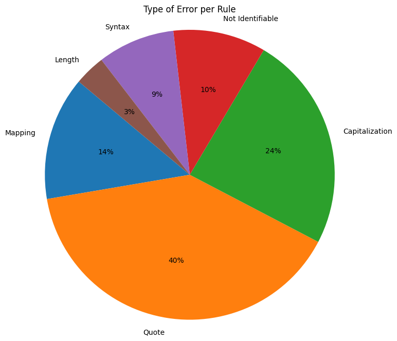

```python
import matplotlib.pyplot as plt


counter_mapping = 0
counter_quote = 0
counter_capitalization = 0
counter_not_identifiable = 0
counter_syntax = 0
counter_length = 0

for rule in final_data:
    for tag in rule['tags']:
        if tag == mapping:
            counter_mapping += 1

        if tag == quote:
            counter_quote += 1

        if tag == capitalization:
            counter_capitalization += 1

        if tag == not_identifiable:
            counter_not_identifiable += 1

        if tag == syntax:
            counter_syntax += 1

        if tag == length:
            counter_length += 1


# Lengths of the lists
lengths = [counter_mapping, counter_quote, counter_capitalization, counter_not_identifiable, counter_syntax, counter_length]

# Labels for the pie chart
labels = ['Mapping', 'Quote', 'Capitalization', 'Not Identifiable', 'Syntax', 'Length']

# Plotting the pie chart
plt.figure(figsize=(8, 8))
plt.pie(lengths, labels=labels, autopct='%1.0f%%', startangle=140)

plt.axis('equal')  # Equal aspect ratio ensures that pie is drawn as a circle.
plt.title('Type of Error per Rule')
plt.show()
```